# HW 1 - Kelly “Scott” Sims

3. Using the k-nearest-neighbors classification function kknn contained in the R kknn package, suggest a good value of k, and show how well it classifies that data points in the full data set. Don’t forget to scale the data (scale=TRUE in kknn).

```r
require("kknn")
data = read.csv("./credit_card_data-headers.csv", header = TRUE)

accuracy_percentage <- rep(0,20)
for(j in 1:20){
      pred = rep(0, nrow(data))
      for(i in 1:nrow(data)){

            model <- kknn(R1~., data[-i,], data[i,], k = j, scale = TRUE)
            pred[i] <- round(fitted(model))

      }

      acc <- sum(pred == as.vector(data[,11])) / nrow(data)
      cat("Finished model with", j, "nearest neightbors......................",(acc*100),"% Accuracy\n")
      accuracy_percentage[j] = acc

}
```

```
## Finished model with 1 nearest neightbors...................... 81.49847 % Accuracy
## Finished model with 2 nearest neightbors...................... 81.49847 % Accuracy
## Finished model with 3 nearest neightbors...................... 81.49847 % Accuracy
## Finished model with 4 nearest neightbors...................... 81.49847 % Accuracy
## Finished model with 5 nearest neightbors...................... 85.1682 % Accuracy
## Finished model with 6 nearest neightbors...................... 84.55657 % Accuracy
## Finished model with 7 nearest neightbors...................... 84.70948 % Accuracy
## Finished model with 8 nearest neightbors...................... 84.86239 % Accuracy
## Finished model with 9 nearest neightbors...................... 84.70948 % Accuracy
## Finished model with 10 nearest neightbors...................... 85.01529 % Accuracy
## Finished model with 11 nearest neightbors...................... 85.1682 % Accuracy
## Finished model with 12 nearest neightbors...................... 85.3211 % Accuracy
## Finished model with 13 nearest neightbors...................... 85.1682 % Accuracy
## Finished model with 14 nearest neightbors...................... 85.1682 % Accuracy
## Finished model with 15 nearest neightbors...................... 85.3211 % Accuracy
## Finished model with 16 nearest neightbors...................... 85.1682 % Accuracy
## Finished model with 17 nearest neightbors...................... 85.1682 % Accuracy
## Finished model with 18 nearest neightbors...................... 85.1682 % Accuracy
## Finished model with 19 nearest neightbors...................... 85.01529 % Accuracy
## Finished model with 20 nearest neightbors...................... 85.01529 % Accuracy
```

```r
cat("\n\nBest performing model is model", which.max(accuracy_percentage),"with an accuracy score of", max(accuracy_percentage))
```

```
##
##
## Best performing model is model 12 with an accuracy score of 0.853211
```

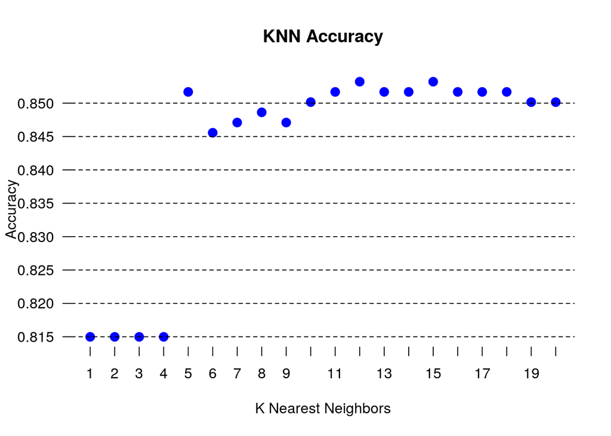

```r
plot(accuracy_percentage, main = "KNN Accuracy", xlab = "K Nearest Neighbors", ylab = "Accuracy", col = "blue", pch=20, cex = 2, axes = FALSE)
axis(1, seq(1,20,1), col = NA, col.ticks = 1)
axis(2, seq(0.80, 0.87, 0.005), col = NA, col.ticks = 1, las=2)
abline(h=seq(0.80, 0.87, 0.005),lty=2,col="black")
```

***Conclusion** It appears that having a K value of 12 is the best perfroming model, with an accuracy score 85.32%. Granted, this doesn’t necessarily mean it is a good classifier, as no precesion or recall statistics have been calculated (confusion matrix) as done with SVM. But it appears to be a good starting point.